# Homework 5

Forecasting: Principles and Practice - Exponential Smoothing

Paul Perez

3/14/2021

# Exercise 7.8 - 1

Consider the `pigs` series - the number of pigs slaughtered in Victoria each month

## a. Use the ses() function in R to find the optimizal values of α and ℓ0, and generate forecasts for the next four months

```r
fc <- ses(pigs, h = 4)
fc
```

```
##          Point Forecast    Lo 80    Hi 80    Lo 95    Hi 95
## Sep 1995       98816.41 85605.43 112027.4 78611.97 119020.8
## Oct 1995       98816.41 85034.52 112598.3 77738.83 119894.0
## Nov 1995       98816.41 84486.34 113146.5 76900.46 120732.4
## Dec 1995       98816.41 83958.37 113674.4 76092.99 121539.8
```

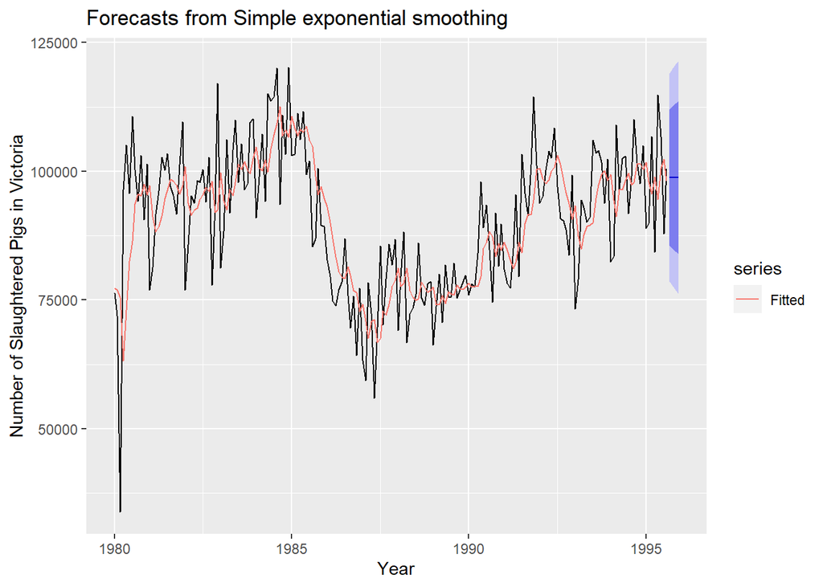

```r
autoplot(fc) +
  autolayer(fitted(fc), series="Fitted") +
  ylab("Number of Slaughtered Pigs in Victoria") + xlab("Year")
```

```r
fc$model
```

```
## Simple exponential smoothing
##
## Call:
##  ses(y = pigs, h = 4)
##
##   Smoothing parameters:
##     alpha = 0.2971
##
##   Initial states:
##     l = 77260.0561
##
##   sigma:  10308.58
##
##      AIC     AICc      BIC
## 4462.955 4463.086 4472.665
```

The optimal alpha is 0.2971 and the optimal l is 77260.0561.

## b. Compute a 95% prediction interval for the first forecast using ^y ± 1.96s where s is the standard deviation of the residuals. Compare your interval with the interval produced by R.

```r
s <- sd(fc$residuals)
high <- fc$mean+1.96*s
low <- fc$mean-1.96*s

high[[1]]
```

```
## [1] 118952.8
```

```r
low[[1]]
```

```
## [1] 78679.97
```

Looking at the `Lo 95` and `Hi 95` from the R formula, 78611.97 and 119020.8 respectively, our manually calculated values, 78679.97 and 118952.8, are very close.

# Exercise 7.8 - 5

Data set `books` contains the daily sales of paperback and hardcover books at the same store. The task is to forecast the next four days’ sales for paperback and hardcover books.

## a. Plot the series and discuss the main features of the data.

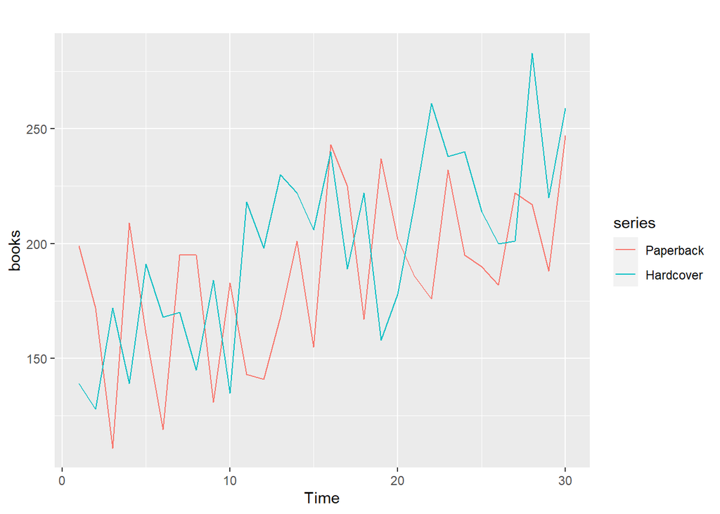

```r
autoplot(books)
```

Initially looking at the graph, we can see that paperback books tend to have peaks while the hardcover books are at their troughs. This is an upward trend.

## b. Use the ses() function to forecast each series, and plot the forecasts.

```r
fc_paper <- ses(books[,"Paperback"], h = 4)
fc_paper
```

```
##    Point Forecast    Lo 80    Hi 80    Lo 95    Hi 95
## 31       207.1097 162.4882 251.7311 138.8670 275.3523
## 32       207.1097 161.8589 252.3604 137.9046 276.3147
## 33       207.1097 161.2382 252.9811 136.9554 277.2639
## 34       207.1097 160.6259 253.5935 136.0188 278.2005
```

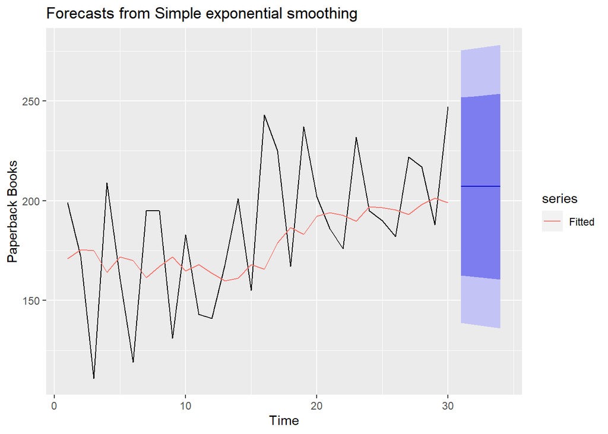

```r
autoplot(fc_paper) +
  autolayer(fitted(fc_paper), series="Fitted") +
  ylab("Paperback Books") + xlab("Time")
```

```r
fc_hard <- ses(books[,"Hardcover"], h = 4)
fc_hard
```

```
##    Point Forecast    Lo 80    Hi 80    Lo 95    Hi 95
## 31       239.5601 197.2026 281.9176 174.7799 304.3403
## 32       239.5601 194.9788 284.1414 171.3788 307.7414
## 33       239.5601 192.8607 286.2595 168.1396 310.9806
## 34       239.5601 190.8347 288.2855 165.0410 314.0792
```

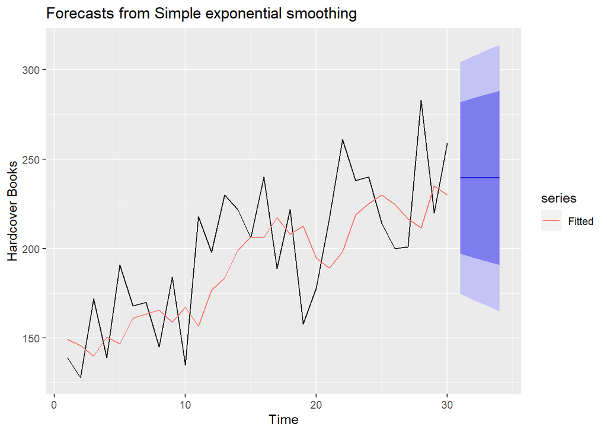

```r
autoplot(fc_hard) +
  autolayer(fitted(fc_hard), series="Fitted") +
  ylab("Hardcover Books") + xlab("Time")
```

## c. Compute the RMSE values for the training data in each case.

```r
accuracy(fc_paper)[2]
```

```
## [1] 33.63769
```

```r
accuracy(fc_hard)[2]
```

```
## [1] 31.93101
```

The RMSE for the paperback books is 33.63769 while the RMSE for the hardcover books is 31.93101.

# Exercise 7.8 - 6

We will continue with the daily sales of paperback and hardcover books in data set `books`.

## a. Apply Holt’s linear method to the paperback and hardback series and compute four-day forecasts in each case.

```r
ht_paper <- holt(books[,"Paperback"], h = 4)
ht_paper
```

```
##    Point Forecast    Lo 80    Hi 80    Lo 95    Hi 95
## 31       209.4668 166.6035 252.3301 143.9130 275.0205
## 32       210.7177 167.8544 253.5811 145.1640 276.2715
## 33       211.9687 169.1054 254.8320 146.4149 277.5225
## 34       213.2197 170.3564 256.0830 147.6659 278.7735
```

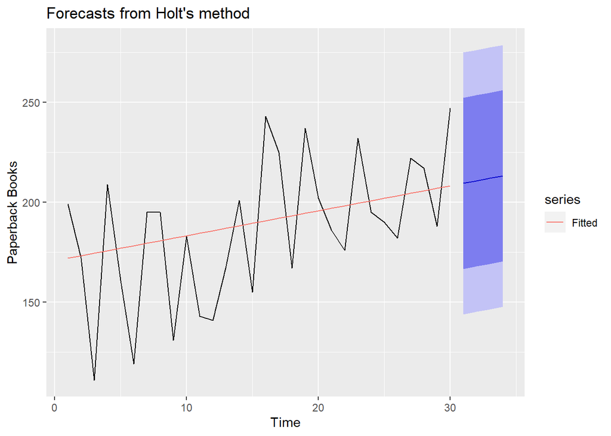

```r
autoplot(ht_paper) +
  autolayer(fitted(ht_paper), series="Fitted") +
  ylab("Paperback Books") + xlab("Time")
```

```r
ht_hard <- holt(books[,"Hardcover"], h = 4)
ht_hard
```

```
##    Point Forecast    Lo 80    Hi 80    Lo 95    Hi 95
## 31       250.1739 212.7390 287.6087 192.9222 307.4256
## 32       253.4765 216.0416 290.9113 196.2248 310.7282
## 33       256.7791 219.3442 294.2140 199.5274 314.0308
## 34       260.0817 222.6468 297.5166 202.8300 317.3334
```

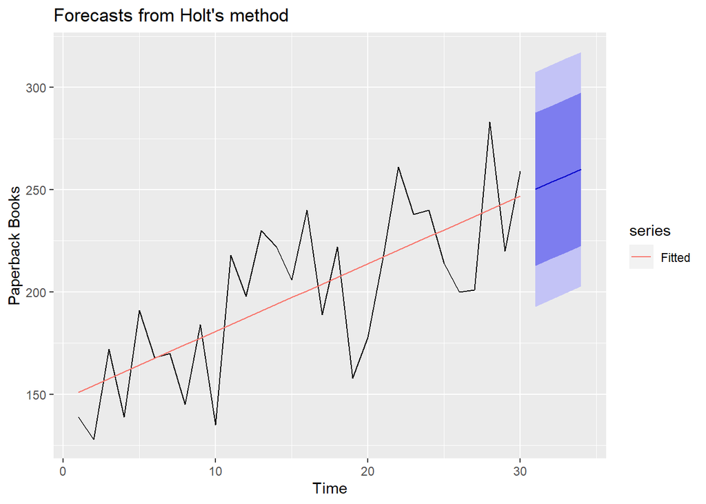

```r
autoplot(ht_hard) +
  autolayer(fitted(ht_hard), series="Fitted") +
  ylab("Paperback Books") + xlab("Time")
```

## b. Compare the RMSE measures of Holt’s method for the two series to those of simple exponential smoothing in the previous question. (Remember that Holt’s method is using one more parameter than SES.) Discuss the merits of the two forecasting methods for these data sets.

```r
accuracy(fc_paper)[2]
```

```
## [1] 33.63769
```

```r
accuracy(fc_hard)[2]
```

```
## [1] 31.93101
```

```r
accuracy(ht_paper)[2]
```

```
## [1] 31.13692
```

```r
accuracy(ht_hard)[2]
```

```
## [1] 27.19358
```

While the RMSE for paperback and hardcover using simple expontial smoothing were 33.63769 and 31.93101 respectively, they were 31.13692 and 27.19358 using Holt’s linear method. The charts above take into account trend and forecast off trend.

## c. Compare the forecasts for the two series using both methods. Which do you think is best?

Considering we just called out trend being accounted for using Holt’s linear method, while also having lower RMSE’s, we would want look to utilize Holt’s as the better fit.

## d. Calculate a 95% prediction interval for the first forecast for each series, using the RMSE values and assuming normal errors. Compare your intervals with those produced using `ses` and `holt`.

### Simple Exponential Smoothing Intervals

```r
s <- sd(fc_paper$residuals)
high <- fc_paper$mean+1.96*s
low <- fc_paper$mean-1.96*s

high[[1]]
```

```
## [1] 272.623
```

```r
low[[1]]
```

```
## [1] 141.5964
```

```r
s <- sd(fc_hard$residuals)
high <- fc_hard$mean+1.96*s
low <- fc_hard$mean-1.96*s

high[[1]]
```

```
## [1] 300.5354
```

```r
low[[1]]
```

```
## [1] 178.5848
```

### Holt’s Linear Intervals

```r
s <- sd(ht_paper$residuals)
high <- ht_paper$mean+1.96*s
low <- ht_paper$mean-1.96*s

high[[1]]
```

```
## [1] 271.0945
```

```r
low[[1]]
```

```
## [1] 147.839
```

```r
s <- sd(ht_hard$residuals)
high <- ht_hard$mean+1.96*s
low <- ht_hard$mean-1.96*s

high[[1]]
```

```
## [1] 304.3838
```

```r
low[[1]]
```

```
## [1] 195.964
```

Comparing the simple exponential and holt linear intervals for the paperback books, the range in limits is greater in the simple exponential. The same case is applicable for the hardcover books as well.

# Exercise 7.8 - 7

For this exercise use data set `eggs`, the price of a dozen eggs in the United States from 1900–1993. Experiment with the various options in the `holt()` function to see how much the forecasts change with damped trend, or with a Box-Cox transformation. Try to develop an intuition of what each argument is doing to the forecasts.

[Hint: use `h=100` when calling `holt()` so you can clearly see the differences between the various options when plotting the forecasts.]

```r
ht_eggs1 <- holt(eggs, h = 100)
ht_eggs1
```

```
##      Point Forecast       Lo 80     Hi 80       Lo 95    Hi 95
## 1994    59.78553313   24.970286  94.60078    6.540207 113.0309
## 1995    57.06372643   12.206005 101.92145  -11.540238 125.6677
## 1996    54.34191973    1.308668 107.37517  -26.765440 135.4493
## 1997    51.62011302   -8.488401 111.72863  -40.307926 143.5482
## 1998    48.89830632  -17.537664 115.33428  -52.706742 150.5034
## 1999    46.17649962  -26.035964 118.38896  -64.262933 156.6159
## 2000    43.45469292  -34.106500 121.01589  -75.164916 162.0743
## 2001    40.73288622  -41.832449 123.29822  -85.539898 167.0057
## 2002    38.01107951  -49.273098 125.29526  -95.478551 171.5007
## 2003    35.28927281  -56.472472 127.05102 -105.048206 175.6268
## 2004    32.56746611  -63.464327 128.59926 -114.300487 179.4354
## 2005    29.84565941  -70.275216 129.96654 -123.276007 182.9673
## 2006    27.12385271  -76.926479 131.17418 -132.007398 186.2551
## 2007    24.40204600  -83.435566 132.23966 -140.521350 189.3254
```

[output cut: 86 more lines]

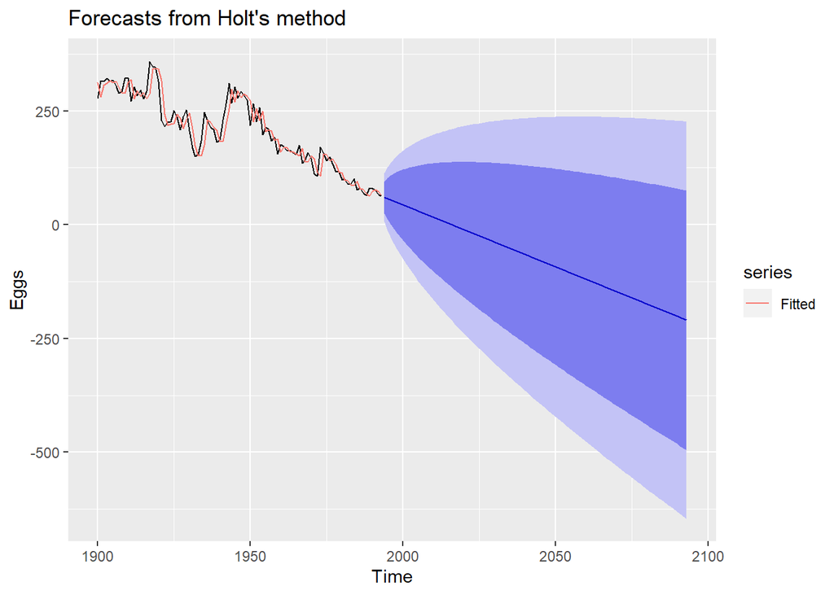

```r
autoplot(ht_eggs1) +
  autolayer(fitted(ht_eggs1), series="Fitted") +
  ylab("Eggs") + xlab("Time")
```

```r
ht_eggs2 <- holt(eggs, damped = TRUE, h = 100)
ht_eggs2
```

```
##      Point Forecast        Lo 80     Hi 80       Lo 95    Hi 95
## 1994       62.84884   27.8938665  97.80381    9.389822 116.3079
## 1995       62.79968   16.9363788 108.66299   -7.342188 132.9416
## 1996       62.76036    8.0760016 117.44472  -20.872149 146.3929
## 1997       62.72890    0.4263979 125.03140  -32.554554 158.0124
## 1998       62.70373   -6.4067675 131.81423  -42.991656 168.3991
## 1999       62.68360  -12.6402008 138.00740  -52.514212 177.8814
## 2000       62.66749  -18.4083657 143.74335  -61.327332 186.6623
## 2001       62.65461  -23.8016345 149.11085  -69.568803 194.8780
## 2002       62.64430  -28.8842950 154.17289  -77.336605 202.6252
## 2003       62.63605  -33.7040638 158.97616  -84.703440 209.9755
## 2004       62.62945  -38.2975438 163.55645  -91.725068 216.9840
## 2005       62.62417  -42.6935603 167.94191  -98.445402 223.6938
## 2006       62.61995  -46.9153057 172.15521 -104.899769 230.1397
## 2007       62.61657  -50.9817746 176.21492 -111.117108 236.3503
```

[output cut: 86 more lines]

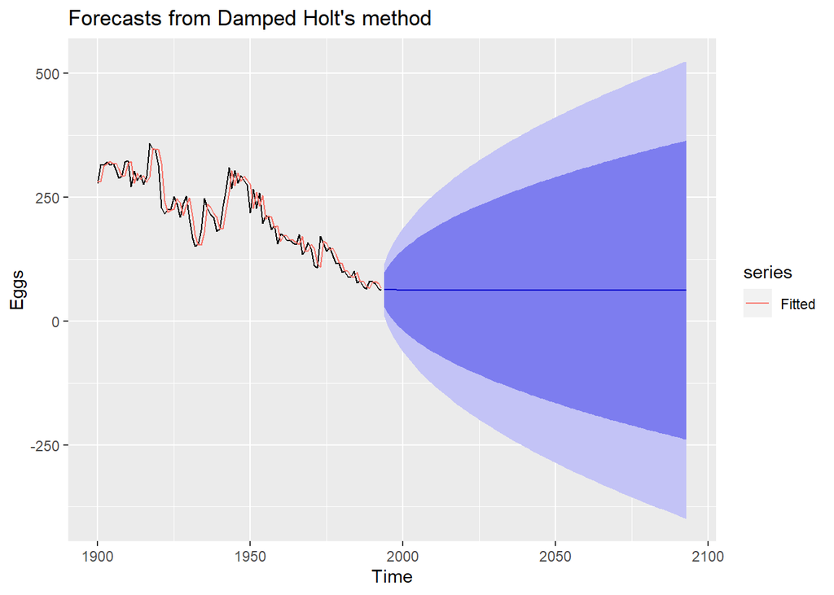

```r
autoplot(ht_eggs2) +
  autolayer(fitted(ht_eggs2), series="Fitted") +
  ylab("Eggs") + xlab("Time")
```

```r
ht_eggs3 <- holt(eggs, lambda = BoxCox.lambda(eggs), h = 100)
ht_eggs3
```

```
##      Point Forecast         Lo 80     Hi 80         Lo 95     Hi 95
## 1994     61.4107603  4.640814e+01  79.02212  3.947196e+01  89.44945
## 1995     60.0421240  4.147646e+01  82.90348  3.327908e+01  96.84743
## 1996     58.6920872  3.751269e+01  85.83783  2.853596e+01 102.79296
## 1997     57.3605616  3.414325e+01  88.19844  2.467300e+01 107.85505
## 1998     56.0474589  3.119333e+01  90.15981  2.142386e+01 112.29946
## 1999     54.7526902  2.856371e+01  91.82084  1.863743e+01 116.27667
## 2000     53.4761662  2.619126e+01  93.24432  1.621764e+01 119.88213
## 2001     52.2177974  2.403270e+01  94.47323  1.409858e+01 123.18111
## 2002     50.9774937  2.205666e+01  95.53860  1.223246e+01 126.22071
## 2003     49.7551646  2.023944e+01  96.46378  1.058319e+01 129.03638
## 2004     48.5507193  1.856257e+01  97.26691  9.122550e+00 131.65559
## 2005     47.3640666  1.701125e+01  97.96245  7.827917e+00 134.10027
## 2006     46.1951148  1.557337e+01  98.56214  6.680721e+00 136.38821
## 2007     45.0437717  1.423883e+01  99.07572  5.665431e+00 138.53416
```

[output cut: 86 more lines]

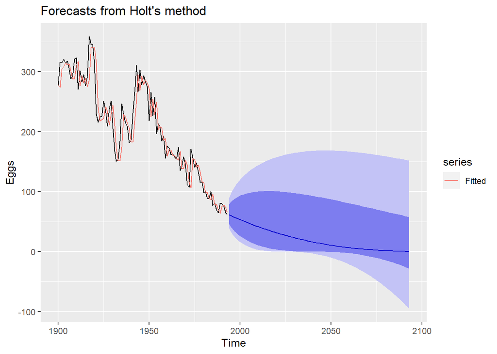

```r
autoplot(ht_eggs3) +
  autolayer(fitted(ht_eggs3), series="Fitted") +
  ylab("Eggs") + xlab("Time")
```

```r
ht_eggs4 <- holt(eggs, lambda = BoxCox.lambda(eggs), damped = TRUE, h = 100)
ht_eggs4
```

```
##      Point Forecast       Lo 80     Hi 80         Lo 95     Hi 95
## 1994       62.64655 47.27973262  80.69832  4.017989e+01  91.39126
## 1995       62.38988 42.92322722  86.41174  3.434621e+01 101.08240
## 1996       62.13895 39.55414540  91.14596  3.000254e+01 109.28536
## 1997       61.89363 36.76017601  95.31306  2.652069e+01 116.62820
## 1998       61.65379 34.35554959  99.09862  2.361805e+01 123.39337
## 1999       61.41930 32.23747696 102.60524  2.113849e+01 129.73689
## 2000       61.19001 30.34192101 105.89676  1.898490e+01 135.75574
## 2001       60.96582 28.62573829 109.01614  1.709192e+01 141.51512
## 2002       60.74659 27.05819232 111.99394  1.541311e+01 147.06137
## 2003       60.53221 25.61644715 114.85283  1.391398e+01 152.42884
## 2004       60.32256 24.28297202 117.61016  1.256811e+01 157.64382
## 2005       60.11752 23.04395071 120.27958  1.135471e+01 162.72698
## 2006       59.91700 21.88825720 122.87206  1.025706e+01 167.69492
## 2007       59.72089 20.80676914 125.39657  9.261488e+00 172.56120
```

[output cut: 86 more lines]

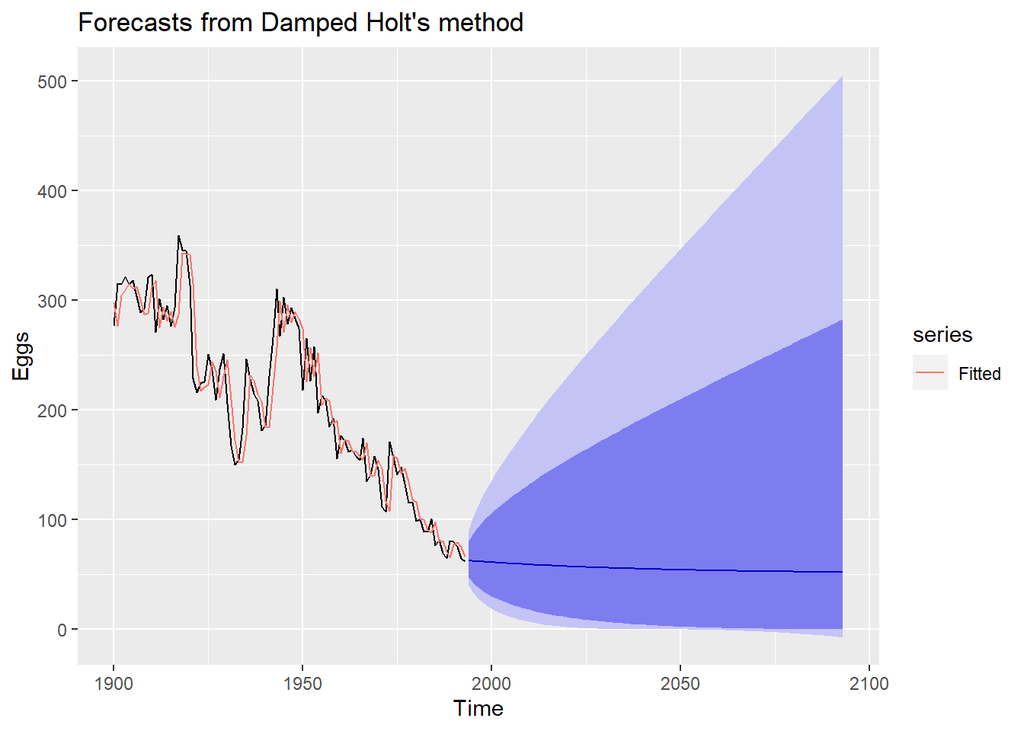

```r
autoplot(ht_eggs4) +
  autolayer(fitted(ht_eggs4), series="Fitted") +
  ylab("Eggs") + xlab("Time")
```

```r
accuracy(ht_eggs1)[2]
```

```
## [1] 26.58219
```

```r
accuracy(ht_eggs2)[2]
```

```
## [1] 26.54019
```

```r
accuracy(ht_eggs3)[2]
```

```
## [1] 26.39376
```

```r
accuracy(ht_eggs4)[2]
```

```
## [1] 26.53321
```

While all of them have very similar RMSE’s, our third model using Holt’s linear function while also applying a Box.Cox lamda transformation and setting h to 100 had the lowest RMSE.

# Exercise 7.8 - 8

Recall your retail time series data (from Exercise 3 in Section 2.10).

## a. Why is multiplicative seasonality necessary for this series?

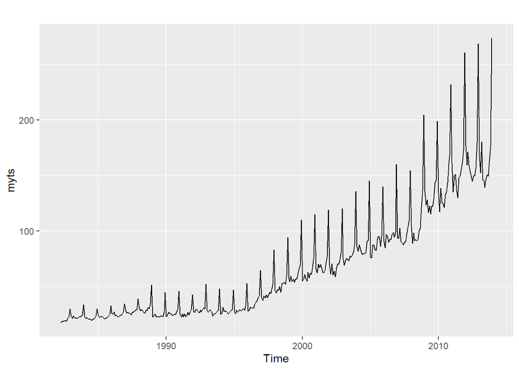

```r
retaildata <- readxl::read_excel("retail.xlsx", skip=1)

myts <- ts(retaildata[,"A3349414R"],
  frequency=12, start=c(1982,4))

autoplot(myts)
```

While there is clearly an uptrend in the data, there are a few years that do not look to be a gradual and consistent increase. It is almost exponential as the dot come bubble hits in the late 1990’s, possibly related.

## b. Apply Holt-Winters’ multiplicative method to the data. Experiment with making the trend damped.

```r
ht_myts1 <- hw(myts, seasonal = "multiplicative", h = 100)
ht_myts1
```

```
##          Point Forecast     Lo 80    Hi 80     Lo 95    Hi 95
## Jan 2014       169.9905 156.06054 183.9204 148.68648 191.2945
## Feb 2014       154.1596 139.53461 168.7845 131.79264 176.5265
## Mar 2014       172.3289 154.02404 190.6337 144.33404 200.3237
## Apr 2014       159.0533 140.52989 177.5768 130.72416 187.3825
## May 2014       153.9913 134.60979 173.3729 124.34981 183.6328
## Jun 2014       149.9225 129.74321 170.1019 119.06092 180.7841
## Jul 2014       155.1829 133.02372 177.3420 121.29338 189.0724
## Aug 2014       158.3369 134.50145 182.1723 121.88374 194.7900
## Sep 2014       162.0118 136.43140 187.5922 122.88996 201.1336
## Oct 2014       171.1247 142.90395 199.3455 127.96477 214.2847
## Nov 2014       182.7797 151.40710 214.1523 134.79946 230.7599
## Dec 2014       273.4089 224.71219 322.1056 198.93372 347.8840
## Jan 2015       172.8378 140.89917 204.7764 123.99189 221.6837
## Feb 2015       156.7381 126.83227 186.6440 111.00106 202.4752
## Mar 2015       175.2074 140.75738 209.6574 122.52066 227.8941
## Apr 2015       161.7064 128.99742 194.4154 111.68232 211.7305
## May 2015       156.5564 124.02945 189.0834 106.81071 206.3021
## Jun 2015       152.4164 119.93494 184.8979 102.74029 202.0925
## Jul 2015       157.7607 123.31848 192.2029 105.08588 210.4355
## Aug 2015       160.9635 125.00382 196.9231 105.96793 215.9590
## Sep 2015       164.6957 127.08441 202.3069 107.17421 222.2171
## Oct 2015       173.9557 133.38508 214.5263 111.90830 236.0031
## Nov 2015       185.7993 141.58350 230.0151 118.17707 253.4216
## Dec 2015       277.9196 210.48756 345.3516 174.79121 381.0479
## Jan 2016       175.6852 132.19824 219.1722 109.17761 242.1929
## Feb 2016       159.3168 119.16907 199.4646  97.91614 220.7175
## Mar 2016       178.0860 132.42668 223.7453 108.25609 247.9159
## Apr 2016       164.3596 121.51084 207.2084  98.82807 229.8912
## May 2016       159.1216 116.96398 201.2793  94.64707 223.5962
## Jun 2016       154.9104 113.22278 196.5980  91.15468 218.6661
## Jul 2016       160.3386 116.53266 204.1446  93.34317 227.3341
## Aug 2016       163.5902 118.23542 208.9450  94.22605 232.9544
## Sep 2016       167.3797 120.30878 214.4506  95.39095 239.3684
## Oct 2016       176.7868 126.37787 227.1957  99.69300 253.8806
## Nov 2016       188.8191 134.25023 243.3880 105.36321 272.2750
## Dec 2016       282.4305 199.73260 365.1284 155.95497 408.9060
## Jan 2017       178.5329 125.53685 231.5289  97.48245 259.5833
## Feb 2017       161.8957 113.23886 210.5525  87.48150 236.3098
## Mar 2017       180.9648 125.91554 236.0141  96.77422 265.1554
```

[output cut: 46 more lines]

```
## Feb 2021       172.2125  96.08415 248.3408  55.78426 288.6407
## Mar 2021       192.4816 106.92734 278.0359  61.63765 323.3256
## Apr 2021       177.6279  98.24852 257.0072  56.22762 299.0281
## May 2021       171.9499  94.69673 249.2031  53.80137 290.0984
## Jun 2021       167.3825  91.78337 242.9816  51.76360 283.0014
## Jul 2021       173.2306  94.58059 251.8806  52.94580 293.5154
## Aug 2021       176.7261  96.07362 257.3785  53.37878 300.0734
## Sep 2021       180.8020  97.86674 263.7372  53.96347 307.6405
## Oct 2021       190.9447 102.91299 278.9764  56.31183 325.5775
## Nov 2021       203.9205 109.43507 298.4060  59.41748 348.4236
## Dec 2021       304.9889 162.97262 447.0053  87.79372 522.1842
## Jan 2022       192.7733 102.53395 283.0127  54.76412 330.7825
## Feb 2022       174.7920  92.57232 257.0117  49.04784 300.5362
## Mar 2022       195.3612 103.02399 287.6984  54.14363 336.5788
## Apr 2022       180.2820  94.66613 265.8978  49.34383 311.2201
```

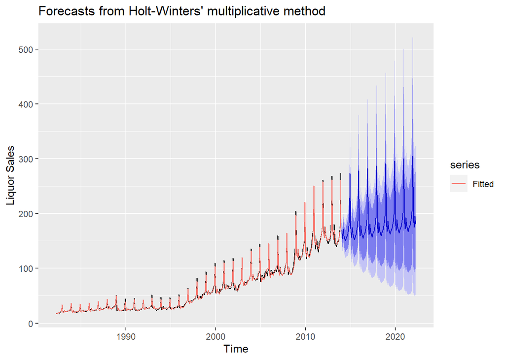

```r
autoplot(ht_myts1) +
  autolayer(fitted(ht_myts1), series="Fitted") +
  ylab("Liquor Sales") + xlab("Time")
```

```r
ht_myts2 <- hw(myts, seasonal = "multiplicative", damped = TRUE, h = 100)
ht_myts2
```

```
##          Point Forecast     Lo 80    Hi 80      Lo 95    Hi 95
## Jan 2014       170.3068 156.60101 184.0126 149.345601 191.2680
## Feb 2014       154.0151 139.59309 168.4372 131.958514 176.0718
## Mar 2014       170.7619 152.76921 188.7547 143.244430 198.2794
## Apr 2014       156.7079 138.51531 174.9005 128.884739 184.5311
## May 2014       152.5995 133.36123 171.8377 123.177119 182.0218
## Jun 2014       147.3560 127.39445 167.3176 116.827435 177.8846
## Jul 2014       153.7471 131.54769 175.9465 119.796029 187.6982
## Aug 2014       157.0526 133.03544 181.0698 120.321512 193.7837
## Sep 2014       159.7746 134.02989 185.5193 120.401472 199.1477
## Oct 2014       169.5709 140.90377 198.2381 125.728299 213.4135
## Nov 2014       182.7370 150.44042 215.0336 133.343621 232.1304
## Dec 2014       272.3696 222.19782 322.5413 195.638493 349.1007
## Jan 2015       172.4893 139.46055 205.5181 121.976171 223.0025
## Feb 2015       155.9471 124.97777 186.9165 108.583588 203.3106
## Mar 2015       172.8587 137.32912 208.3883 118.520896 227.1965
## Apr 2015       158.5914 124.91384 192.2691 107.085994 210.0969
## May 2015       154.3950 120.57611 188.2138 102.673501 206.1164
## Jun 2015       149.0533 115.42513 182.6814  97.623470 200.4831
## Jul 2015       155.4807 119.39751 191.5639 100.296229 210.6652
## Aug 2015       158.7862 120.92531 196.6472 100.882943 216.6895
## Sep 2015       161.5012 121.97986 201.0226 101.058519 221.9439
## Oct 2015       171.3650 128.36953 214.3604 105.609121 237.1208
## Nov 2015       184.6298 137.17862 232.0810 112.059470 257.2002
## Dec 2015       275.1317 202.76109 347.5023 164.450402 385.8130
## Jan 2016       174.2020 127.34096 221.0630 102.534239 245.8697
## Feb 2016       157.4631 114.17654 200.7497  91.262002 223.6643
## Mar 2016       174.5040 125.51494 223.4931  99.581689 249.4263
## Apr 2016       160.0695 114.20839 205.9306  89.931004 230.2080
## May 2016       155.8039 110.27404 201.3337  86.172004 225.4357
## Jun 2016       150.3851 105.58691 195.1833  81.872188 218.8980
## Jul 2016       156.8410 109.23925 204.4428  84.040382 229.6417
## Aug 2016       160.1466 110.65033 209.6429  84.448579 235.8446
## Sep 2016       162.8561 111.62363 214.0886  84.502799 241.2094
## Oct 2016       172.7727 117.47479 228.0707  88.201816 257.3437
## Nov 2016       186.1151 125.53580 246.6944  93.467055 278.7632
## Dec 2016       277.2992 185.54504 369.0533 136.973341 417.6250
## Jan 2017       175.5459 116.52060 234.5711  85.274512 265.8172
## Feb 2017       158.6528 104.46447 212.8410  75.778924 241.5266
## Mar 2017       175.7951 114.82395 236.7663  82.547769 269.0425
```

[output cut: 46 more lines]

```
## Feb 2021       161.3447  69.67215 253.0173  21.143621 301.5458
## Mar 2021       178.7167  76.40218 281.0312  22.240158 335.1932
## Apr 2021       163.8538  69.34277 258.3648  19.311657 308.3959
## May 2021       159.4112  66.77820 252.0443  17.741232 301.0812
## Jun 2021       153.7951  63.76696 243.8233  16.108937 291.4813
## Jul 2021       160.3241  65.78925 254.8589  15.745527 304.9026
## Aug 2021       163.6297  66.44864 260.8108  15.004080 312.2554
## Sep 2021       166.3251  66.83647 265.8138  14.170352 318.4799
## Oct 2021       176.3772  70.12825 282.6262  13.883439 338.8710
## Nov 2021       189.9180  74.70917 305.1269  13.721273 366.1148
## Dec 2021       282.8487 110.07293 455.6245  18.610947 547.0865
## Jan 2022       178.9868  68.90099 289.0727  10.625061 347.3486
## Feb 2022       161.6987  61.56724 261.8301   8.560850 314.8365
## Mar 2022       179.1008  67.44323 290.7585   8.335250 349.8664
## Apr 2022       164.1989  61.14574 267.2521   6.592686 321.8051
```

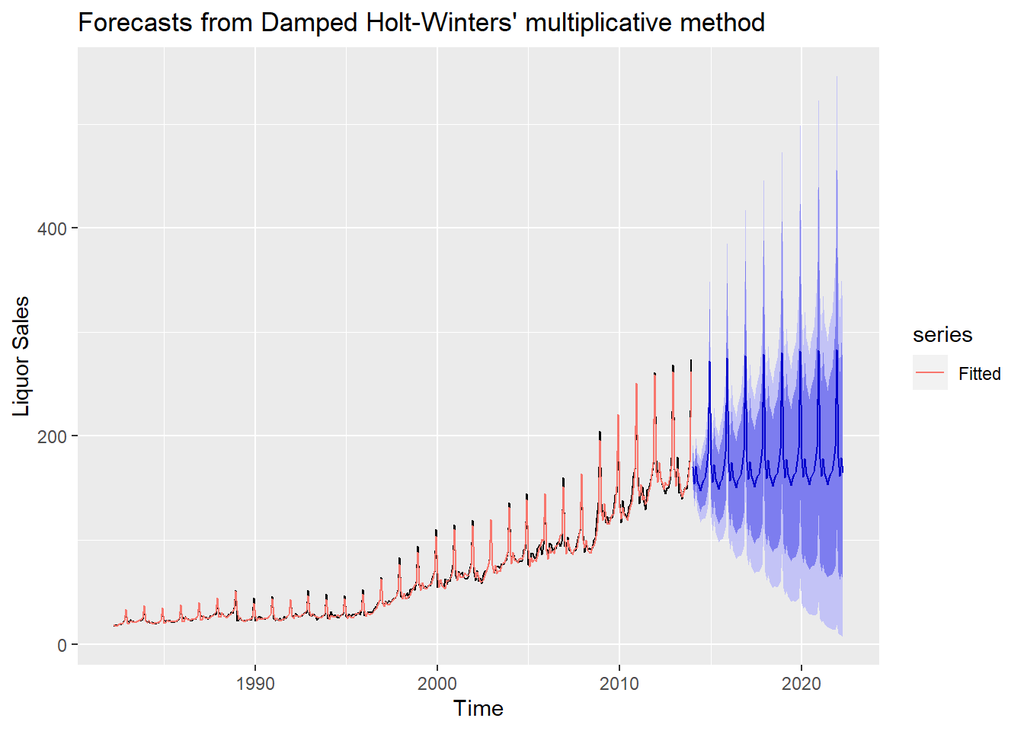

```r
autoplot(ht_myts2) +
  autolayer(fitted(ht_myts2), series="Fitted") +
  ylab("Liquor Sales") + xlab("Time")
```

## c. Compare the RMSE of the one-step forecasts from the two methods. Which do you prefer?

```r
accuracy(ht_myts1)[2]
```

```
## [1] 4.237051
```

```r
accuracy(ht_myts2)[2]
```

```
## [1] 4.147425
```

In this instance, unlike the last question, the dampened model yields a lower RMSE.

## d. Check that the residuals from the best method look like white noise.

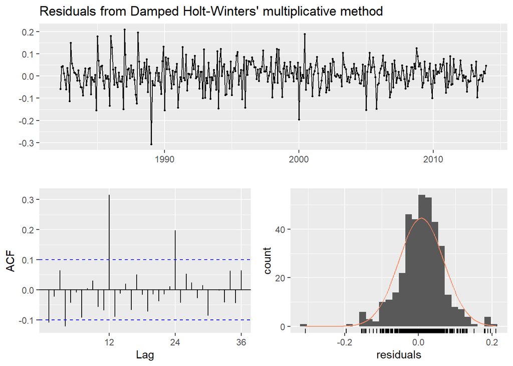

```
##
##  Ljung-Box test
##
## data:  Residuals from Damped Holt-Winters' multiplicative method
## Q* = 84.18, df = 7, p-value = 1.887e-15
##
## Model df: 17.   Total lags used: 24
```

```r
checkresiduals(ht_myts2)
```

## e. Now find the test set RMSE, while training the model to the end of 2010. Can you beat the seasonal naïve approach from Exercise 8 in Section 3.7?

```r
myts.train <- window(myts, end=c(2010,12))
myts.test <- window(myts, start=2011)
```

```r
n_myts <- snaive(myts.train)
n_myts
```

```
##          Point Forecast    Lo 80    Hi 80     Lo 95    Hi 95
## Jan 2011          134.8 123.6507 145.9493 117.74858 151.8514
## Feb 2011          117.1 105.9507 128.2493 100.04858 134.1514
## Mar 2011          138.3 127.1507 149.4493 121.24858 155.3514
## Apr 2011          125.6 114.4507 136.7493 108.54858 142.6514
## May 2011          124.5 113.3507 135.6493 107.44858 141.5514
## Jun 2011          121.0 109.8507 132.1493 103.94858 138.0514
## Jul 2011          132.4 121.2507 143.5493 115.34858 149.4514
## Aug 2011          135.3 124.1507 146.4493 118.24858 152.3514
## Sep 2011          143.5 132.3507 154.6493 126.44858 160.5514
## Oct 2011          161.2 150.0507 172.3493 144.14858 178.2514
## Nov 2011          167.8 156.6507 178.9493 150.74858 184.8514
## Dec 2011          232.1 220.9507 243.2493 215.04858 249.1514
## Jan 2012          134.8 119.0325 150.5675 110.68565 158.9143
## Feb 2012          117.1 101.3325 132.8675  92.98565 141.2143
## Mar 2012          138.3 122.5325 154.0675 114.18565 162.4143
## Apr 2012          125.6 109.8325 141.3675 101.48565 149.7143
## May 2012          124.5 108.7325 140.2675 100.38565 148.6143
## Jun 2012          121.0 105.2325 136.7675  96.88565 145.1143
## Jul 2012          132.4 116.6325 148.1675 108.28565 156.5143
## Aug 2012          135.3 119.5325 151.0675 111.18565 159.4143
## Sep 2012          143.5 127.7325 159.2675 119.38565 167.6143
## Oct 2012          161.2 145.4325 176.9675 137.08565 185.3143
## Nov 2012          167.8 152.0325 183.5675 143.68565 191.9143
## Dec 2012          232.1 216.3325 247.8675 207.98565 256.2143
```

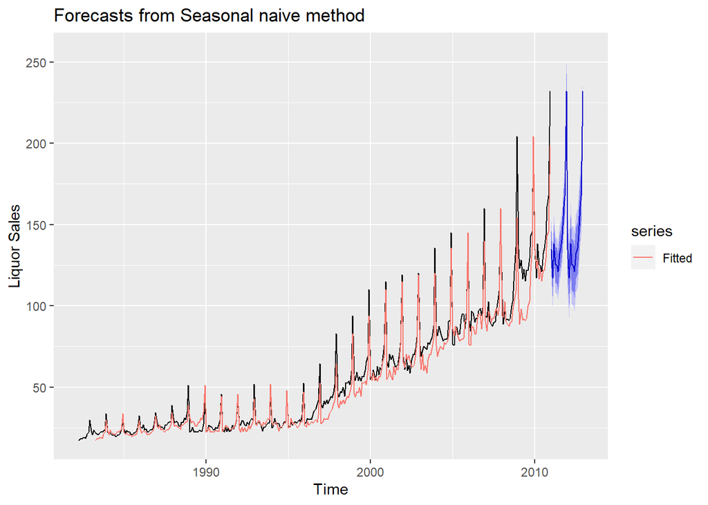

```r
autoplot(n_myts) +
  autolayer(fitted(n_myts), series="Fitted") +
  ylab("Liquor Sales") + xlab("Time")
```

```r
ht_myts3 <- hw(myts.train, seasonal = "multiplicative", damped = TRUE, h = 100)
ht_myts3
```

```
##          Point Forecast     Lo 80    Hi 80       Lo 95    Hi 95
## Jan 2011       148.3303 136.18607 160.4746 129.7572961 166.9033
## Feb 2011       137.1202 124.04466 150.1957 117.1229016 157.1174
## Mar 2011       150.7606 134.52756 166.9936 125.9343124 175.5869
## Apr 2011       139.7324 123.07940 156.3855 114.2638129 165.2010
## May 2011       139.5556 121.40237 157.7089 111.7926137 167.3187
## Jun 2011       134.6640 115.74208 153.5859 105.7254289 163.6025
## Jul 2011       139.9108 118.84461 160.9770 107.6928446 172.1287
## Aug 2011       142.9313 120.01730 165.8453 107.8873655 177.9752
## Sep 2011       146.8905 121.94866 171.8323 108.7452566 185.0357
## Oct 2011       157.0335 128.91545 185.1516 114.0306364 200.0364
## Nov 2011       166.8132 135.43219 198.1941 118.8201083 214.8062
## Dec 2011       246.6197 198.03324 295.2062 172.3131011 320.9264
## Jan 2012       152.9755 121.50133 184.4497 104.8399021 201.1111
## Feb 2012       141.2390 110.96573 171.5124  94.9400061 187.5381
## Mar 2012       155.1049 120.54628 189.6636 102.2520469 207.9578
## Apr 2012       143.5956 110.40226 176.7890  92.8307540 194.3605
## May 2012       143.2578 108.96174 177.5539  90.8064777 195.7092
## Jun 2012       138.0923 103.90840 172.2762  85.8125452 190.3720
## Jul 2012       143.3293 106.69539 179.9633  87.3025522 199.3561
## Aug 2012       146.2834 107.72986 184.8370  87.3208283 205.2461
## Sep 2012       150.1975 109.42905 190.9660  87.8475200 212.5475
## Oct 2012       160.4277 115.63102 205.2243  91.9171197 228.9382
## Nov 2012       170.2749 121.41311 219.1368  95.5472205 245.0027
## Dec 2012       251.5341 177.42876 325.6394 138.1997744 364.8684
## Jan 2013       155.9028 108.78856 203.0170  83.8477840 227.9578
## Feb 2013       143.8347  99.28543 188.3839  75.7025010 211.9668
## Mar 2013       157.8426 107.77721 207.9080  81.2741863 234.4110
## Apr 2013       146.0301  98.63075 193.4295  73.5390431 218.5212
## May 2013       145.5909  97.26502 193.9167  71.6828574 219.4989
## Jun 2013       140.2527  92.67668 187.8288  67.4914410 213.0140
## Jul 2013       145.4836  95.08079 195.8864  68.3991500 222.5681
## Aug 2013       148.3959  95.91840 200.8734  68.1384910 228.6533
## Sep 2013       152.2816  97.34403 207.2191  68.2618603 236.3012
## Oct 2013       162.5666 102.76727 222.3659  71.1114298 254.0217
## Nov 2013       172.4565 107.80605 237.1069  73.5821887 271.3308
## Dec 2013       254.6310 157.39556 351.8664 105.9222275 403.3398
## Jan 2014       157.7475  96.41323 219.0818  63.9448195 251.5502
## Feb 2014       145.4704  87.90591 203.0348  57.4331274 233.5076
## Mar 2014       159.5679  95.33072 223.8050  61.3256268 257.8101
```

[output cut: 46 more lines]

```
## Feb 2018       147.8181  45.83517 249.8011  -8.1513517 303.7876
## Mar 2018       162.0442  49.34400 274.7444 -10.3158736 334.4042
## Apr 2018       149.7663  44.77377 254.7589 -10.8059327 310.3386
## May 2018       149.1714  43.77015 254.5727 -12.0259229 310.3688
## Jun 2018       143.5684  41.33362 245.8031 -12.7861804 299.9229
## Jul 2018       148.7898  42.01794 255.5617 -14.5036730 312.0833
## Aug 2018       151.6379  41.98995 261.2859 -16.0541650 319.3300
## Sep 2018       155.4800  42.20284 268.7571 -17.7624443 328.7224
## Oct 2018       165.8492  44.11213 287.5863 -20.3315968 352.0300
## Nov 2018       175.8045  45.80294 305.8062 -23.0157482 374.6248
## Dec 2018       259.3840  66.16981 452.5981 -36.1115771 554.8795
## Jan 2019       160.5787  40.09444 281.0630 -23.6860767 344.8435
## Feb 2019       147.9808  36.14955 259.8120 -23.0503106 319.0118
## Mar 2019       162.2157  38.75291 285.6785 -26.6043325 351.0357
## Apr 2019       149.9189  35.00946 264.8282 -25.8198955 325.6576
```

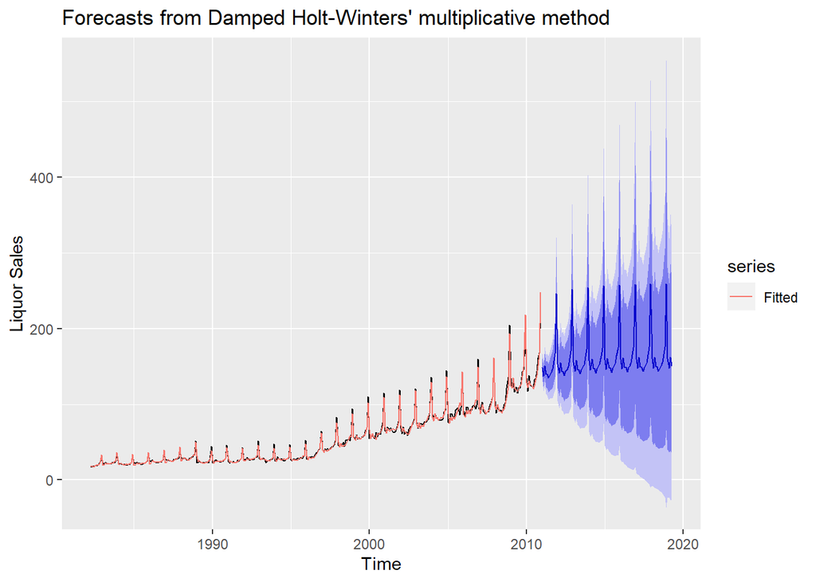

```r
autoplot(ht_myts3) +
  autolayer(fitted(ht_myts3), series="Fitted") +
  ylab("Liquor Sales") + xlab("Time")
```

```r
accuracy(n_myts)[2]
```

```
## [1] 8.699864
```

```r
accuracy(ht_myts3)[2]
```

```
## [1] 3.717405
```

The RMSE for the naive model produced a higher RMSE than the dampened model.